| title: “Case Study: Spam Email Prediction” |
| --- |
| author: “Jaclyn Coate, Megan Riley, Reagan Meagher” |
| date: “2/13/2021” |
| output: pdf_document |

# Introduction

The digital world is something that has increasingly changed the way organizations and businesses communicate with their consumers. As digital memory becomes more cost effective it takes no effort at all for a company to render and send large volumes of emails in an attempt to engage their end users. While is a positive shift for companies in their effort to grow their business, consumers are inundated with spam emails that are problematic for those who use their email for other purposes than just shopping. Individuals can easily spot their spam emails and skip or delete them. But this manual effort can be strenuous and take a long time based on sheer volume of spam emails alone. This may not be a big issue for the casual email users who only use it for online shopping and occasional correspondence. But the individuals who live in the digital world would much rather not spend their time sorting email, but rather leveraging their email for their end goals.

This leads us to the case study we present today; below are our efforts to make sure we have a strong spam email filter to take the burden off of email users for manually filtering their spam emails out. The first question is how to apply a filter that effectively filters spam emails. Our process for an automatic procedure closely resembles the process a human might go through in order to determine if their email is spam. We review the *subject line* and if we can’t tell from that we examine the *body* without ever opening an *attachment* in case of a virus. With cleaning and examining these different elements of an email programmatically we can leverage extremely powerful machine learning algorithmic classifiers such as: *NaiveBayes*, *Decisions Tree Classifier*, and *XGBoost*/*Support Vector Machine*.

```
## [1] "pt_PT.ISO8859-1/pt_PT.ISO8859-1/pt_PT.ISO8859-1/C/pt_PT.ISO8859-1/en_US.UTF-8"
```

# Data Cleaning

The nature of user created text email messages is messy and mixed due to user error, inconsistencies and other issues created by human communication. Building these raw text files into comprehensible data structures to classify spam emails requires heavy cleaning, standardization which will come with loss of precision over ability to use data.

Before beginning in order to avoid errors, we followed instructor’s and fellow student’s advice to manually remove three emails of interest in the spam folder. One was known as an actual file of commands that would not process as an email, the other two were known to create issues in processing. These three emails were dropped before coded processing began.

To manage the several thousand emails of various formattings we processed the emails from their raw text form into a quantifiable list of words that is available for each email in the corpus. The major function used is the ProcessAllWords function which is built off of several helper functions.

The cleaning functions took the task of listing out all included file names in the overall directory provided, eliminating the command files from each folder. With the list of files available the function then read the lines of each email into a list of messages. That message list was split into headers and bodies. The attachments were then dropped from the bodies. When the clean text of each email’s body was parsed out, we split each email body into a list of unique words with the exclusion of single characters, and a given list of stop words.

Below is a full breakdown of functions leveraged in order to grab, split, identify boundaries, and many more cleaning requiremetns in order to processing the languages contained within email messages.

```r
splitMessage = function(msg) {
  splitPoint = match("", msg)
  header = msg[1:(splitPoint-1)]
  body = msg[ -(1:splitPoint) ]
  return(list(header = header, body = body))
}
getBoundary = function(header) {
  boundaryIdx = grep("boundary=", header)
  boundary = gsub('"', "", header[boundaryIdx])
  gsub(".*boundary= *([^;]*);?.*", "\\1", boundary)
}
dropAttach = function(body, boundary){

  bString = paste("--", boundary, sep = "")
  bStringLocs = which(bString == body)

  if (length(bStringLocs) <= 1) return(body)

  eString = paste("--", boundary, "--", sep = "")
  eStringLoc = which(eString == body)
  if (length(eStringLoc) == 0)
    return(body[ (bStringLocs[1] + 1) : (bStringLocs[2] - 1)])

  n = length(body)
  if (eStringLoc < n)
     return( body[ c( (bStringLocs[1] + 1) : (bStringLocs[2] - 1),
                    ( (eStringLoc + 1) : n )) ] )

  return( body[ (bStringLocs[1] + 1) : (bStringLocs[2] - 1) ])
}
findMsgWords =
function(msg, stopWords) {
 if(is.null(msg))
  return(character())
 words = unique(unlist(strsplit(cleanText(msg), "[[:blank:]\t]+")))

 # drop empty and 1 letter words
 words = words[ nchar(words) > 1]
 words = words[ !( words %in% stopWords) ]
 invisible(words)
}
cleanText =
function(msg)   {
  tolower(gsub("[[:punct:]0-9[:space:][:blank:]]+", " ", msg))
}
processAllWords = function(dirName, stopWords)
{
       # read all files in the directory
  fileNames = list.files(dirName, full.names = TRUE)
       # drop files that are not email, i.e., cmds
  notEmail = grep("cmds$", fileNames)
  if ( length(notEmail) > 0) fileNames = fileNames[ - notEmail ]
  messages = lapply(fileNames, readLines, encoding = "latin1")

       # split header and body
  emailSplit = lapply(messages, splitMessage)
       # put body and header in own lists
  bodyList = lapply(emailSplit, function(msg) msg$body)
  headerList = lapply(emailSplit, function(msg) msg$header)
  rm(emailSplit)

       # determine which messages have attachments
  hasAttach = sapply(headerList, function(header) {
    CTloc = grep("Content-Type", header)
    if (length(CTloc) == 0) return(0)
    multi = grep("multi", tolower(header[CTloc]))
    if (length(multi) == 0) return(0)
    multi
  })

  hasAttach = which(hasAttach > 0)

       # find boundary strings for messages with attachments
  boundaries = sapply(headerList[hasAttach], getBoundary)

       # drop attachments from message body
  bodyList[hasAttach] = mapply(dropAttach, bodyList[hasAttach],
                               boundaries, SIMPLIFY = FALSE)

       # extract words from body
  msgWordsList = lapply(bodyList, findMsgWords, stopWords)

  invisible(msgWordsList)
}
```

Below we build a directory path locally on one machine, with the overall directory, messages can be processed by the previous functions. The stop words of interest are also cleaned and set up using a general stop word lexicon for this process.

```r
#Directory paths
spamPath = "/Users/zmartygirl/githubrepos1/7333_Quantifying_The_World/Unit6_CaseStudy3/data"
dirNames = list.files(path = paste(spamPath, sep = .Platform$file.sep))
fullDirNames = paste(spamPath, dirNames, sep = .Platform$file.sep)
#Set up Stop Words
stopWords = stopwords()
cleanSW = tolower(gsub("[[:punct:]0-9[:blank:]]+", " ", stopWords))
SWords = unlist(strsplit(cleanSW, "[[:blank:]]+"))
SWords = SWords[ nchar(SWords) > 1 ]
stopWords = unique(SWords)
```

With preparations done, we can load all the available messages into our session and clean and organize them into a set of words for each message. The entirety of this happens within the *processAllWords* function. We can see we have over nine thousand messages, with 5051, 1400, and 500 in separate directories of non spam emails and 998 and 1396 emails in the spam category.

```
## [1] 5051 1400  500  998 1396
```

We then add a label of spam or not spam to every message in our spam corpus. We know our first three directories are not spam and our final two are spam, so they are labeled as such below.

```r
#Below we are adding the true labels on if messagse are spam or not spam. This is our known determination because it was hand labeled.
isSpam = rep(c(FALSE, FALSE, FALSE, TRUE, TRUE), numMsgs)
msgWordsList = unlist(msgWordsList, recursive = FALSE)
```

Below we are creating a classification test dataset. There is potential for no words in the training data. Below we are calculating the log odds without new words.

```
## [1] 31.6979
```

```
## [1] -412.5668
```

Analyzing from a logical perspective we can note that *spam* emails often contain words that might be difficult for detectors to pick up, such as repetitive letters to change the n_grams of the words and *leet speak*. *Leet speak* is the practice of replacing words with letters and such as an *E* becomes a *3* or an *0* becomse a *0*.

Since the Naive Bayes approach cannot easily classify these nuanced characteristic we perform a *decision tree classifier* and an *XGBoost* analysis to compare results.

```r
# do not run twice
testLLR = sapply(testMsgWords, computeMsgLLR, trainTable)
tapply(testLLR, testIsSpam, summary)
```

```
## $`FALSE`
##     Min.  1st Qu.   Median     Mean  3rd Qu.     Max.
## -1375.36  -130.35  -101.54  -118.87   -81.26   107.88
##
## $`TRUE`
##      Min.   1st Qu.    Median      Mean   3rd Qu.      Max.
##   -67.680     4.138    51.738   136.758   126.221 23536.680
```

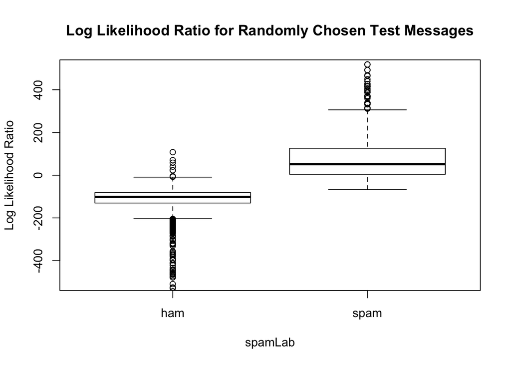

```r
# boxplots of log likelihoods
#pdf("SP_Boxplot.pdf", width = 6, height = 6)
spamLab = c("ham", "spam")[1 + testIsSpam]
boxplot(testLLR ~ spamLab,
        ylab = "Log Likelihood Ratio",
       main = "Log Likelihood Ratio for Randomly Chosen Test Messages",
        ylim=c(-500, 500))
```

```r
#dev.off()
```

```r
typeIErrorRate =
function(tau, llrVals, spam)
{
  classify = llrVals > tau
  sum(classify & !spam)/sum(!spam)
}
#tau 0
typeIErrorRate(0, testLLR,testIsSpam)
```

```
## [1] 0.002589555
```

```r
#tau -20
typeIErrorRate(-20, testLLR,testIsSpam)
```

```
## [1] 0.005610703
```

```r
typeIErrorRates =
function(llrVals, isSpam)
{
  o = order(llrVals)
  llrVals =  llrVals[o]
  isSpam = isSpam[o]
  idx = which(!isSpam)
  N = length(idx)
  list(error = (N:1)/N, values = llrVals[idx])
}
```

Below this code demonstrates misclassifications and calculates type II error rates with a function given the logged likelihood values and true data.

```r
typeIIErrorRates = function(llrVals, isSpam) {

  o = order(llrVals)
  llrVals =  llrVals[o]
  isSpam = isSpam[o]


  idx = which(isSpam)
  N = length(idx)
  list(error = (1:(N))/N, values = llrVals[idx])
  }
xI = typeIErrorRates(testLLR, testIsSpam)
xII = typeIIErrorRates(testLLR, testIsSpam)
tau01 = round(min(xI$values[xI$error <= 0.01]))
t2 = max(xII$error[ xII$values < tau01 ])
```

### Type I versus Type II Error Rates and Log-Likelihood Thresholds

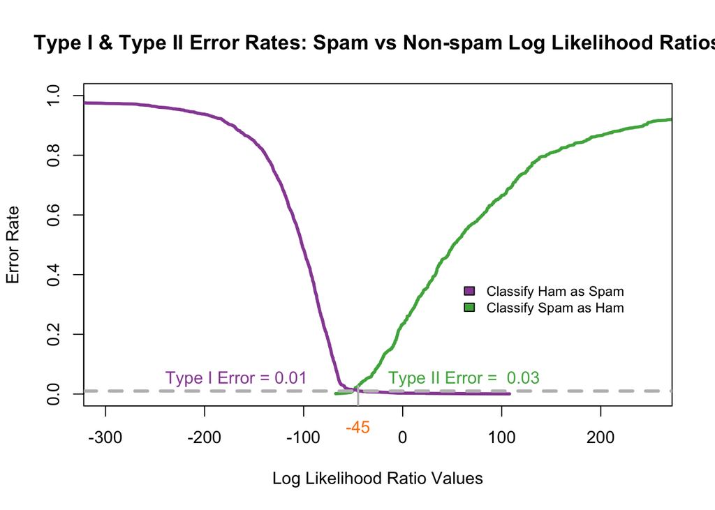

```r
#pdf("LinePlotTypeI+IIErrors.pdf", width = 8, height = 6)

cols = brewer.pal(9, "Set1")[c(3, 4, 5)]
plot(xII$error ~ xII$values,  type = "l", col = cols[1], lwd = 3,
     xlim = c(-300, 250), ylim = c(0, 1),
     xlab = "Log Likelihood Ratio Values", ylab="Error Rate", main = "Type I & Type II Error Rates: Spam vs Non-spam Log Likelihood Ratios")
points(xI$error ~ xI$values, type = "l", col = cols[2], lwd = 3)
legend(x = 50, y = 0.4, fill = c(cols[2], cols[1]),
       legend = c("Classify Ham as Spam",
                  "Classify Spam as Ham"), cex = 0.8,
       bty = "n")
abline(h=0.01, col ="grey", lwd = 3, lty = 2)
text(-250, 0.05, pos = 4, "Type I Error = 0.01", col = cols[2])
mtext(tau01, side = 1, line = 0.5, at = tau01, col = cols[3])
segments(x0 = tau01, y0 = -.50, x1 = tau01, y1 = t2,
         lwd = 2, col = "grey")
text(tau01 + 20, 0.05, pos = 4,
     paste("Type II Error = ", round(t2, digits = 2)),
     col = cols[1])
```

```r
#Below we are obtaining a tau so that one type of error is withint 1% using our 5-fold cross-validation.
#dev.off()
k = 5
numTrain = length(trainMsgWords)
partK = sample(numTrain)
tot = k * floor(numTrain/k)
partK = matrix(partK[1:tot], ncol = k)
testFoldOdds = NULL
for (i in 1:k) {
  foldIdx = partK[ , i]
  trainTabFold = computeFreqs(trainMsgWords[-foldIdx], trainIsSpam[-foldIdx])
  testFoldOdds = c(testFoldOdds,
               sapply(trainMsgWords[ foldIdx ], computeMsgLLR, trainTabFold))
}
testFoldSpam = NULL
for (i in 1:k) {
  foldIdx = partK[ , i]
  testFoldSpam = c(testFoldSpam, trainIsSpam[foldIdx])
}
xFoldI = typeIErrorRates(testFoldOdds, testFoldSpam)
xFoldII = typeIIErrorRates(testFoldOdds, testFoldSpam)
tauFoldI = round(min(xFoldI$values[xFoldI$error <= 0.01]))
tFold2 = xFoldII$error[ xFoldII$values < tauFoldI ]
```

# Feature Creation

Borrowing off of the provided exploration of the messages we used code provided to build a thurough list of features and created dataset to run models with.

In the below chunk hidden from written output we build a list of functions used to create a derived dataset. This includes facotrs such as if the email uses excessive capitalization or if it is a reply to someone, a forward, includes underscors or a dear sir or madam address. All of these factors are fairly simple derivations of the pure messages and able to better describe some unique choices made by the email authors that may give hints as to whether they are spam or ham emails.

```r
readEmail = function(dirName) {
       # retrieve the names of files in directory
  fileNames = list.files(dirName, full.names = TRUE)
       # drop files that are not email
  notEmail = grep("cmds$", fileNames)
  if ( length(notEmail) > 0) fileNames = fileNames[ - notEmail ]
       # read all files in the directory
  lapply(fileNames, readLines, encoding = "latin1")
}

processHeader = function(header)
{
       # modify the first line to create a key:value pair
  header[1] = sub("^From", "Top-From:", header[1])

  headerMat = read.dcf(textConnection(header), all = TRUE)
  headerVec = unlist(headerMat)

  dupKeys = sapply(headerMat, function(x) length(unlist(x)))
  names(headerVec) = rep(colnames(headerMat), dupKeys)

  return(headerVec)
}

processAttach = function(body, contentType){

  boundary = getBoundary(contentType)

  bString = paste("--", boundary, "$", sep = "")
  bStringLocs = grep(bString, body)

  eString = paste("--", boundary, "--$", sep = "")
  eStringLoc = grep(eString, body)

  n = length(body)

  if (length(eStringLoc) == 0) eStringLoc = n + 1
  if (length(bStringLocs) == 1) attachLocs = NULL
  else attachLocs = c(bStringLocs[-1],  eStringLoc)
  msg = body[ (bStringLocs[1] + 1) : min(n, (bStringLocs[2] - 1), na.rm = TRUE)]

  if ( eStringLoc < n )
    msg = c(msg, body[ (eStringLoc + 1) : n ])

  if ( !is.null(attachLocs) ) {
    attachLens = diff(attachLocs, lag = 1)
    attachTypes = mapply(function(begL, endL) {
      contentTypeLoc = grep("[Cc]ontent-[Tt]ype", body[ (begL + 1) : (endL - 1)])
      contentType = body[ begL + contentTypeLoc]
      contentType = gsub('"', "", contentType )
      MIMEType = sub(" *Content-Type: *([^;]*);?.*", "\\1", contentType)
      return(MIMEType)
    }, attachLocs[-length(attachLocs)], attachLocs[-1])
  }

  if (is.null(attachLocs)) return(list(body = msg, attachInfo = NULL) )
  else return(list(body = msg,
                   attachDF = data.frame(aLen = attachLens,
                                         aType = attachTypes,
                                         stringsAsFactors = FALSE)))
}

getMessageRecipients =
  function(header)
  {
    c(if("To" %in% names(header))  header[["To"]] else character(0),
      if("Cc" %in% names(header))  header[["Cc"]] else character(0),
      if("Bcc" %in% names(header)) header[["Bcc"]] else character(0)
    )
  }


processAllEmail = function(dirName, isSpam = FALSE)
{
       # read all files in the directory
  messages = readEmail(dirName)
  fileNames = names(messages)
  n = length(messages)

       # split header from body
  eSplit = lapply(messages, splitMessage)
  rm(messages)
       # process header as named character vector
  headerList = lapply(eSplit, function(msg)
                                 processHeader(msg$header))

       # extract content-type key
  contentTypes = sapply(headerList, function(header)
                                       header["Content-Type"])

       # extract the body
  bodyList = lapply(eSplit, function(msg) msg$body)
  rm(eSplit)
       # which email have attachments
  #hasAttach = grep("^ *multi", tolower(contentTypes))
       # get summary stats for attachments and the shorter body
  #attList = mapply(processAttach, bodyList[hasAttach],  contentTypes[hasAttach], SIMPLIFY = FALSE)
  #old:
  hasAttach = sapply(headerList, function(header) {
    CTloc = grep("Content-Type", header)
    if (length(CTloc) == 0) return(0)
    multi = grep("multi", tolower(header[CTloc]))
    if (length(multi) == 0) return(0)
    multi
  })

  hasAttach = which(hasAttach > 0)

       # find boundary strings for messages with attachments
  boundaries = sapply(headerList[hasAttach], getBoundary)

       # drop attachments from message body
  bodyList[hasAttach] = mapply(dropAttach, bodyList[hasAttach],
                               boundaries, SIMPLIFY = FALSE)

  #new?
  #bodyList[hasAttach] = lapply(attList, function(attEl)  attEl$body)

  #attachInfo = vector("list", length = n )
  #attachInfo[ hasAttach ] = lapply(attList, function(attEl) attEl$attachDF)

       # prepare return structure
  ####
  #  emailList = mapply(function(header, body, attach, isSpam) {
  #                     list(isSpam = isSpam, header = header,
  #                          body = body, attach = attach)
  #                   },
  #                   headerList, bodyList, attachInfo,
  #                   rep(isSpam, n), SIMPLIFY = FALSE )

  ####
  emailList = mapply(function(header, body, isSpam) {
                       list(isSpam = isSpam, header = header,
                            body = body)
                     },
                     headerList, bodyList,
                     rep(isSpam, n), SIMPLIFY = FALSE )
  names(emailList) = fileNames

  invisible(emailList)
}
emailStruct = mapply(processAllEmail, fullDirNames, isSpam = rep( c(FALSE, TRUE), 3:2))
emailStruct = unlist(emailStruct, recursive = FALSE)
```

```r
createDerivedDF =
function(email = emailStruct, operations = funcList,
         verbose = FALSE)
{
  els = lapply(names(operations),
               function(id) {
                 if(verbose) print(id)
                 e = operations[[id]]
                 v = if(is.function(e))
                        sapply(email, e)
                      else
                        sapply(email, function(msg) eval(e))
                 v
         })
   df = as.data.frame(els)
   names(df) = names(operations)
   invisible(df)
}

SpamCheckWords =
  c("viagra", "pounds", "free", "weight", "guarantee", "million",
    "dollars", "credit", "risk", "prescription", "generic", "drug",
    "financial", "save", "dollar", "erotic", "million", "barrister",
    "beneficiary", "easy",
    "money back", "money", "credit card")


emailDF = createDerivedDF(emailStruct)
```

# Models

Below we run with minimal output the creation of several helper functions that will enable us to smoothly run each model.

```r
setupRnum = function(data) {
  logicalVars = which(sapply(data, is.logical))
  facVars = lapply(data[ , logicalVars],
                   function(x) {
                      x = as.numeric(x)
                   })
  cbind(facVars, data[ , - logicalVars])
}

emailDFnum = setupRnum(emailDF)
emailDFnum[is.na(emailDFnum)]<-0
cv_folds <- createFolds(emailDFnum$isSpam, k=5, list=TRUE, returnTrain = TRUE)
#Folds should be equal in length about 7500

#Sets up F1 measurement
f1 <- function(data, lev = NULL, model = NULL) {
  f1_val <- F1_Score(y_pred = data$pred, y_true = data$obs, positive = lev[1])
  p <- Precision(y_pred = data$pred, y_true = data$obs, positive = lev[1])
  r <- Recall(y_pred = data$pred, y_true = data$obs, positive = lev[1])
  fp <-sum(data$pred==0 & data$obs==1)/length(data$pred)

  fn <-sum(data$pred==1 & data$obs==0)/length(data$pred)
    c(F1 = f1_val,
    prec = p,
    rec = r,
    Type_I_err=fp,
    Type_II_err=fn
   )
}
```

## Naive Bayes Model

```r
nb_grid<-expand.grid(laplace=c(0,0.1,0.3,0.5,1), usekernel=c(T,F), adjust=c(T,F))
train_control<-trainControl(method="cv", number=3, savePredictions = 'final',summaryFunction = f1)
model_nb<-caret::train(as.factor(isSpam) ~ .,data=emailDFnum, trControl = train_control, method='naive_bayes',tuneGrid = nb_grid)
model_nb
```

```
## Naive Bayes
##
## 9345 samples
##   29 predictor
##    2 classes: '0', '1'
##
## No pre-processing
## Resampling: Cross-Validated (3 fold)
## Summary of sample sizes: 6230, 6230, 6230
## Resampling results across tuning parameters:
##
##   laplace  usekernel  adjust  F1         prec       rec        Type_I_err
##   0.0      FALSE      FALSE   0.9189204  0.9157884  0.9221695  0.06313537
##   0.0      FALSE       TRUE   0.9189204  0.9157884  0.9221695  0.06313537
##   0.0       TRUE      FALSE         NaN        NaN        NaN         NaN
##   0.0       TRUE       TRUE   0.8926972  0.8075032  0.9981298  0.17720706
##   0.1      FALSE      FALSE   0.9189204  0.9157884  0.9221695  0.06313537
##   0.1      FALSE       TRUE   0.9189204  0.9157884  0.9221695  0.06313537
##   0.1       TRUE      FALSE         NaN        NaN        NaN         NaN
##   0.1       TRUE       TRUE   0.8926972  0.8075032  0.9981298  0.17720706
##   0.3      FALSE      FALSE   0.9189204  0.9157884  0.9221695  0.06313537
##   0.3      FALSE       TRUE   0.9189204  0.9157884  0.9221695  0.06313537
##   0.3       TRUE      FALSE         NaN        NaN        NaN         NaN
##   0.3       TRUE       TRUE   0.8926972  0.8075032  0.9981298  0.17720706
##   0.5      FALSE      FALSE   0.9189204  0.9157884  0.9221695  0.06313537
##   0.5      FALSE       TRUE   0.9189204  0.9157884  0.9221695  0.06313537
##   0.5       TRUE      FALSE         NaN        NaN        NaN         NaN
##   0.5       TRUE       TRUE   0.8926972  0.8075032  0.9981298  0.17720706
##   1.0      FALSE      FALSE   0.9189204  0.9157884  0.9221695  0.06313537
##   1.0      FALSE       TRUE   0.9189204  0.9157884  0.9221695  0.06313537
##   1.0       TRUE      FALSE         NaN        NaN        NaN         NaN
##   1.0       TRUE       TRUE   0.8926972  0.8075032  0.9981298  0.17720706
##   Type_II_err
##   0.057891921
##   0.057891921
##           NaN
##   0.001391118
##   0.057891921
##   0.057891921
##           NaN
##   0.001391118
##   0.057891921
##   0.057891921
##           NaN
##   0.001391118
##   0.057891921
##   0.057891921
##           NaN
##   0.001391118
##   0.057891921
##   0.057891921
##           NaN
##   0.001391118
##
## F1 was used to select the optimal model using the largest value.
## The final values used for the model were laplace = 0, usekernel =
##  FALSE and adjust = FALSE.
```

```r
table(model_nb$pred['Resample'])
```

```
##
## Fold1 Fold2 Fold3
##  3115  3115  3115
```

```r
val<-seq(from = 0, to=0.01, by=0.0005)
```

## Decision Trees and RandomForest Models

```r
cart_grid<-expand.grid(cp=val)
train_control<-trainControl(method="cv", number =5, savePredictions = 'final',summaryFunction = f1)
model_rpart<-caret::train(as.factor(isSpam) ~ .,data=emailDFnum, trControl = train_control, method='rpart',tuneGrid = cart_grid)
model_rpart
```

```
## CART
##
## 9345 samples
##   29 predictor
##    2 classes: '0', '1'
##
## No pre-processing
## Resampling: Cross-Validated (5 fold)
## Summary of sample sizes: 7476, 7476, 7475, 7476, 7477
## Resampling results across tuning parameters:
##
##   cp      F1         prec       rec        Type_I_err  Type_II_err
##   0.0000  0.9622643  0.9578092  0.9667671  0.03167458  0.02471916
##   0.0005  0.9623641  0.9572960  0.9674866  0.03210262  0.02418412
##   0.0010  0.9617037  0.9553082  0.9682057  0.03370753  0.02364890
##   0.0015  0.9607443  0.9534234  0.9682059  0.03520617  0.02364878
##   0.0020  0.9584176  0.9535922  0.9633149  0.03488520  0.02728675
##   0.0025  0.9574095  0.9528541  0.9620195  0.03541887  0.02825029
##   0.0030  0.9570291  0.9529487  0.9611563  0.03531186  0.02889229
##   0.0035  0.9533638  0.9484309  0.9585659  0.03894954  0.03082074
##   0.0040  0.9530773  0.9520707  0.9542497  0.03584645  0.03403084
##   0.0045  0.9535542  0.9529738  0.9542497  0.03509750  0.03403067
##   0.0050  0.9522848  0.9554430  0.9493576  0.03306433  0.03766898
##   0.0055  0.9503335  0.9508048  0.9500770  0.03670355  0.03713371
##   0.0060  0.9492845  0.9517967  0.9469115  0.03574047  0.03948791
##   0.0065  0.9478764  0.9497272  0.9461921  0.03734578  0.04002289
##   0.0070  0.9472730  0.9485522  0.9461923  0.03830886  0.04002278
##   0.0075  0.9471968  0.9485460  0.9460484  0.03830886  0.04012979
##   0.0080  0.9467896  0.9477428  0.9460484  0.03895063  0.04012979
##   0.0085  0.9454424  0.9449004  0.9463355  0.04130374  0.03991617
##   0.0090  0.9452093  0.9424518  0.9482060  0.04322991  0.03852505
##   0.0095  0.9448134  0.9426711  0.9471988  0.04301577  0.03927452
##   0.0100  0.9448134  0.9426711  0.9471988  0.04301577  0.03927452
##
## F1 was used to select the optimal model using the largest value.
## The final value used for the model was cp = 5e-04.
```

```r
library(randomForest)
rf_grid<-expand.grid(mtry=seq(from =1, to = 25, by = 2))
train_control<-trainControl(method="cv", number=3, savePredictions = 'final',summaryFunction = f1)
model_rf<-caret::train(as.factor(isSpam) ~ .,data=emailDFnum, trControl = train_control, ntree=200,method='rf',tuneGrid = rf_grid)
model_rf
```

```
## Random Forest
##
## 9345 samples
##   29 predictor
##    2 classes: '0', '1'
##
## No pre-processing
## Resampling: Cross-Validated (3 fold)
## Summary of sample sizes: 6230, 6230, 6230
## Resampling results across tuning parameters:
##
##   mtry  F1         prec       rec        Type_I_err  Type_II_err
##    1    0.8809720  0.7883076  0.9984175  0.19957196  0.00117710
##    3    0.9746624  0.9645037  0.9850381  0.02696629  0.01112895
##    5    0.9811648  0.9768996  0.9854697  0.01733547  0.01080792
##    7    0.9817022  0.9793882  0.9840311  0.01540931  0.01187801
##    9    0.9821176  0.9806432  0.9835995  0.01444623  0.01219904
##   11    0.9819724  0.9804945  0.9834556  0.01455324  0.01230605
##   13    0.9811222  0.9790865  0.9831679  0.01562333  0.01252006
##   15    0.9817637  0.9799387  0.9835995  0.01498127  0.01219904
##   17    0.9809190  0.9782551  0.9835995  0.01626538  0.01219904
##   19    0.9809646  0.9796308  0.9823047  0.01519529  0.01316212
##   21    0.9807645  0.9786598  0.9828802  0.01594436  0.01273408
##   23    0.9808433  0.9783893  0.9833118  0.01615837  0.01241306
##   25    0.9803251  0.9786399  0.9820170  0.01594436  0.01337614
##
## F1 was used to select the optimal model using the largest value.
## The final value used for the model was mtry = 9.
```

```r
library(xgboost)
xgb_grid<-expand.grid(nrounds = 100, max_depth = c(3,5,7,9,11), eta = c(0.01,0.03,0.1), gamma=c(1,3,5,10), colsample_bytree=1, min_child_weight=1, subsample=1)
train_control<-trainControl(method="cv", number=3, savePredictions = 'final',summaryFunction = f1)
model_xgb<-caret::train(as.factor(isSpam) ~ .,data=emailDFnum, trControl = train_control,method='xgbTree',tuneGrid = xgb_grid)
model_xgb
```

```
## eXtreme Gradient Boosting
##
## 9345 samples
##   29 predictor
##    2 classes: '0', '1'
##
## No pre-processing
## Resampling: Cross-Validated (3 fold)
## Summary of sample sizes: 6230, 6230, 6230
## Resampling results across tuning parameters:
##
##   eta   max_depth  gamma  F1         prec       rec        Type_I_err
##   0.01   3          1     0.9305287  0.9022154  0.9607251  0.07747459
##   0.01   3          3     0.9309761  0.9031830  0.9605812  0.07661851
##   0.01   3          5     0.9313501  0.9032498  0.9613005  0.07661851
##   0.01   3         10     0.9299285  0.9013278  0.9604373  0.07822365
##   0.01   5          1     0.9481307  0.9367790  0.9598619  0.04826110
##   0.01   5          3     0.9478138  0.9357429  0.9602935  0.04911717
##   0.01   5          5     0.9474701  0.9352091  0.9601496  0.04954521
##   0.01   5         10     0.9475139  0.9356994  0.9597180  0.04911717
##   0.01   7          1     0.9566871  0.9491146  0.9644655  0.03852327
##   0.01   7          3     0.9561607  0.9476524  0.9648971  0.03970037
##   0.01   7          5     0.9557937  0.9474862  0.9643217  0.03980738
##   0.01   7         10     0.9545551  0.9468511  0.9624514  0.04023542
##   0.01   9          1     0.9617169  0.9549723  0.9686376  0.03402889
##   0.01   9          3     0.9613402  0.9550662  0.9677744  0.03392188
##   0.01   9          5     0.9602179  0.9552379  0.9653287  0.03370787
##   0.01   9         10     0.9576462  0.9542384  0.9611567  0.03434992
##   0.01  11          1     0.9668197  0.9594002  0.9743922  0.03071161
##   0.01  11          3     0.9644952  0.9580308  0.9710833  0.03167469
##   0.01  11          5     0.9628202  0.9572427  0.9684937  0.03220974
##   0.01  11         10     0.9596114  0.9569681  0.9623076  0.03220974
##   0.03   3          1     0.9405161  0.9195935  0.9624514  0.06260032
##   0.03   3          3     0.9405934  0.9195986  0.9625953  0.06260032
##   0.03   3          5     0.9403112  0.9193243  0.9623076  0.06281434
##   0.03   3         10     0.9404943  0.9199269  0.9620199  0.06227929
##   0.03   5          1     0.9582420  0.9476771  0.9690692  0.03980738
##   0.03   5          3     0.9580508  0.9470447  0.9693569  0.04034243
##   0.03   5          5     0.9576731  0.9471254  0.9684937  0.04023542
##   0.03   5         10     0.9559365  0.9445585  0.9676306  0.04226859
```

[output cut: 88 more lines]

```
##   0.01968967
##   0.01027287
##   0.01423221
##   0.01647940
##   0.01947566
##
## Tuning parameter 'nrounds' was held constant at a value of 100
##  1
## Tuning parameter 'min_child_weight' was held constant at a value of
##  1
## Tuning parameter 'subsample' was held constant at a value of 1
## F1 was used to select the optimal model using the largest value.
## The final values used for the model were nrounds = 100, max_depth =
##  11, eta = 0.1, gamma = 1, colsample_bytree = 1, min_child_weight = 1
##  and subsample = 1.
```